# EPI 569: Homework 4 - Analysis of 2018/19 Ebola outbreak in Democratic Republic of Congo – Severity and Epidemic Growth

Author

Victoria Ngo

```r
library(kableExtra, warn.conflicts=F, quietly=T)
library(dplyr, warn.conflicts=F, quietly=T)
library(ggplot2, warn.conflicts=F, quietly=T)
library(earlyR, warn.conflicts=F, quietly=T)
library(incidence, warn.conflicts=F, quietly=T)
```

# Background 1

The second largest ever Ebola virus disease outbreak occurred in 2018/19 in the Democratic Republic of Congo. For your reference, you can find the Situation Reports (SitRep) for the outbreak on the WHO website.

https://www.who.int/emergencies/diseases/ebola/drc-2019/situation-reports

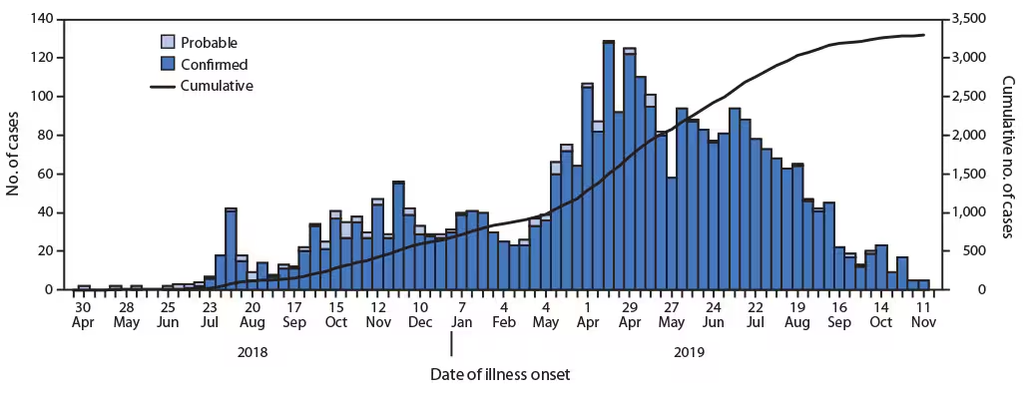

```r
knitr::include_graphics(here::here("04. OutbreakEpi exercise", "drc_ebola_v2.png"), dpi = 10)
```

## Question 1

What would have been the best time to intervene in this outbreak and why?

**ANSWER BELOW**

The best time to intervene would be May 28th, when the second and third probable Ebola Virus cases appeared. This timing is crucial due to the delay in confirmed case detection during the incubation phase. This delay implies that there is more Ebola Virus transmission in the community than there are confirmed cases.

By intervening by May 28th, this ensures that there are procedures and interventions in place when Ebola cases become confirmed.

# Background 2

We’ll now focus on the first few weeks of the outbreak. All the information you need for this exercise is contained below and in the data files in the links.

```r
drc_ebola <- read.csv("https://raw.githubusercontent.com/blopman/epi569/master/DRC_Ebola_CFR.csv") # Read in the data
```

Here are the cases (Grey Bars) and deaths based on week of death (Blue Bars) and death based on week of case’s onset (Black line) from the first few weeks of the outbreak

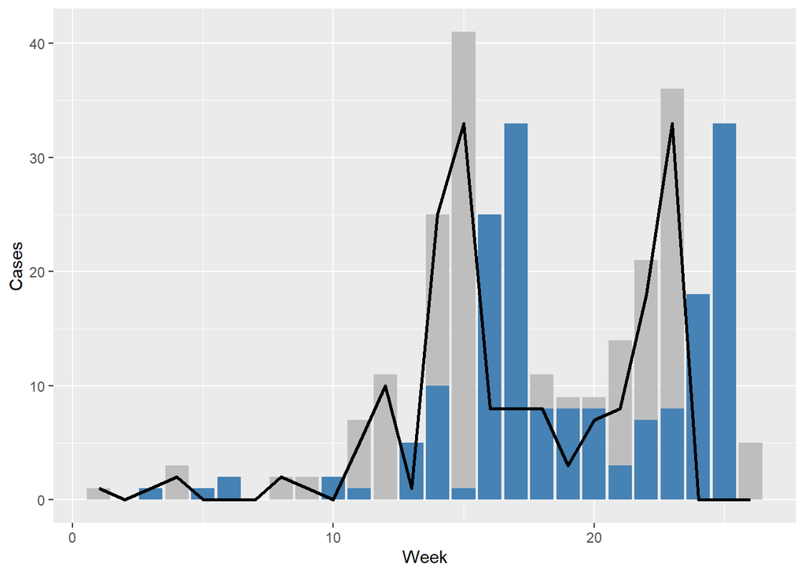

```r
ggplot(drc_ebola, aes(x = Week)) +
  geom_col(aes(y = Cases), fill = "grey") +
  geom_col(aes(y = Deaths._in_week), fill = "steelblue") +
  geom_line(aes(y = Deaths._from_onset_in_week), color = "black",  size = 1)
```

We can calculate and plot the crude CFR (Blue) and adjusted CFR (Black) as follows

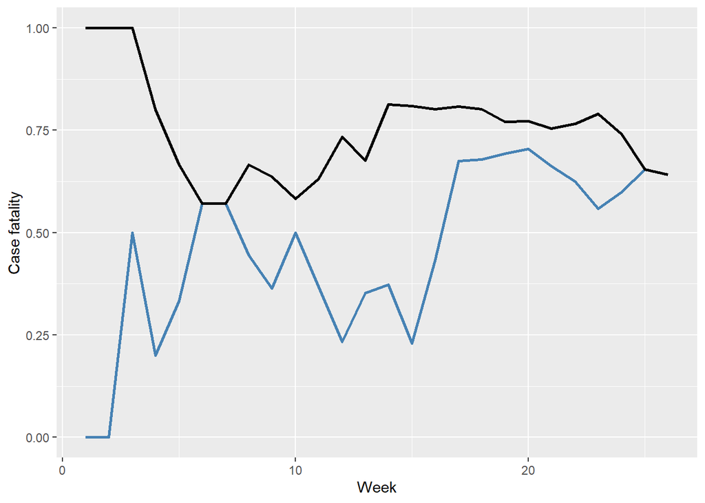

```r
drc_ebola %>%
  mutate(cum_cases = cumsum(Cases)) %>%
  mutate(cum_crude_deaths = cumsum(Deaths._in_week)) %>%
  mutate(cum_adjusted_deaths = cumsum(Deaths._from_onset_in_week)) %>%
  mutate(crude_cfr = cum_crude_deaths/cum_cases) %>%
  mutate(adjusted_cfr = cum_adjusted_deaths/cum_cases) -> drc_ebola

ggplot(drc_ebola, aes(x = Week)) +
  geom_line(aes(y = crude_cfr), color = "steelblue", size = 1) +
  geom_line(aes(y = adjusted_cfr), color = "black", size = 1) +
  ylab("Case fatality")
```

## Question 2

1. Explain the differences between the crude CFR and the adjusted CFR that is based on date of onset of the deceased case.

**ANSWER BELOW**

The crude CFR starts at 0.00 at the beginning of the outbreak because deaths have not occurred or been reported, leading to an initially low case fatality. Over time, as more cases are confirmed and deaths are reported, the crude CFR gradually increases but does so at a slower rate. This is due to having a large denominator inclusive of all confirmed cases without accounting for the lag between symptom onset and death.

2. Why is the crude CFR lower than the adjusted CFR?

**ANSWER BELOW**

The crude CFR is lower than the adjusted CFR because it does not account for the time lag between the onset of symptoms and death. This means the crude CFR has a large sensitive denominator, driving down the crude CFR value. The adjusted CFR considers this delay, leading to a quicker recognition of fatal cases, especially early in the outbreak. In contrast, the crude CFR rises more slowly because it includes all cases, including those that are still unresolved, resulting in a lower initial estimate. Over time, as more cases reach an outcome, both rates converge to the same value, reflecting a more accurate fatality rate.

3. Why does the adjusted CFR appear to decline in the last few weeks?

**Note:** *If we had line-lists of cases (which we do not here), we could also calculate the CFRs based on known outcomes (survived or died).*

# Background 3

Now, lets turn to calculating the $R_0$ from the initial growth rate from the beginning of the outbreak. First, import the case counts from the first few weeks of the outbreak.

```r
r0_ebola <- read.csv("https://raw.githubusercontent.com/blopman/epi569/master/DRC_Ebola_week.csv")
```

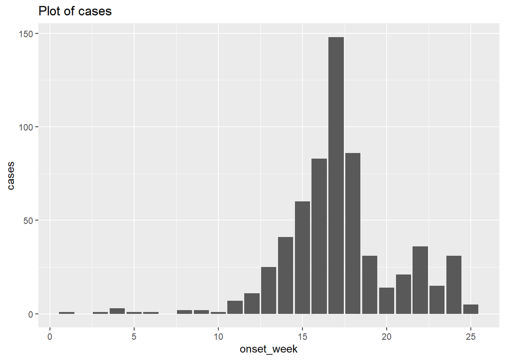

```r
ggplot(r0_ebola, aes(onset_week, cases)) +
  geom_bar(stat="identity") +
  ggtitle("Plot of cases")
```

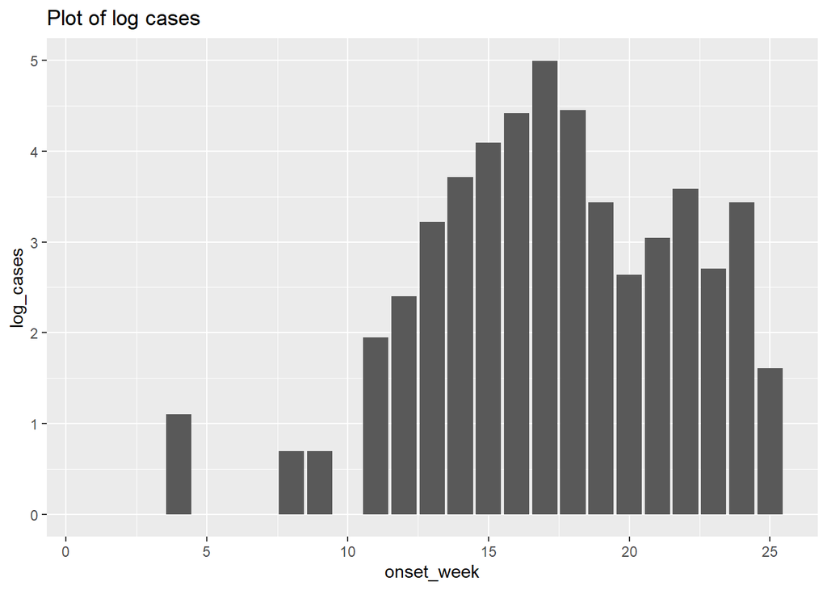

```r
r0_ebola %>%
  mutate(log_cases = log(cases)) -> r0_ebola

ggplot(r0_ebola, aes(onset_week, log_cases)) +
  geom_bar(stat="identity") +
  ggtitle("Plot of log cases")
```

## Question 3

1. In order to calculate the basic reproductive number based on initial growth of the epidemic, which time interval would you use?

**ANSWER BELOW**

I would use weeks 11-17.

2. Why did you select this time?

**ANSWER BELOW**

Weeks 11 to 17 show a strong rise in cases and log cases. This is the time when there is a supportive transmission amount of secondary cases to say there’s an outbreak.

Add those weeks by changing R code below:

```r
start_week <- 11 #change this number
end_week <- 17 #change this number
```

## Question 4

What is your calculation for the basic reproductive number?

**ANSWER BELOW**

```r
r0_ebola %>%
  filter(onset_week>=start_week, onset_week <= end_week) %>%
  splitstackshape::expandRows("cases", drop = FALSE) %>%
  select(onset_week) %>%
  pull(onset_week) -> linelist
i <- incidence(linelist)

mu <- 3 # mean in weeks                     #Generation time of ebola is about 21 days or 3 weeks
sigma <- 3 # standard deviation in weeks

res <- get_R(i, si_mean = mu, si_sd = sigma)
R_val <- sample_R(res, 1000)
mean(R_val)
```

```
[1] 3.292192
```

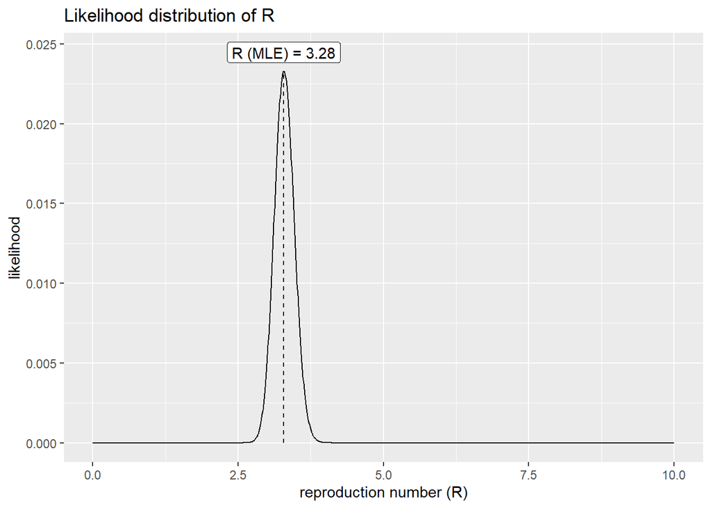

```r
#This plot shows the likelihood distribution of the R estimate
plot(res)
```

## Question 5

Next, test at least 2 different scenarios to see how your estimate of $R_0$ changes when selecting different start/end weeks for exponential growth. Potential scenarios to consider might include:

- What happens if you include time before or after when exponential growth is occurring?
- What happens if you include periods of decreasing case counts?

Summarize your findings in the table shell below, rounding $R_0$ to 2 decimal places (n.nn). Briefly describe (~2-3 sentences) how your choice of time period affects the $R_0$ estimate.

```r
##Scenario 1
# Choose start/end week. Change values of scen1_start and scen1_end

scen1_start <- 0 #XX
scen1_end <-  11 #YY

# Estimate Ro
r0_ebola %>%
  filter(onset_week>=scen1_start, onset_week <= scen1_end) %>%
  splitstackshape::expandRows("cases", drop = FALSE) %>%
  select(onset_week) %>%
  pull(onset_week) -> linelist
i <- incidence(linelist)

mu <- 3 # mean in weeks                     #Generation time of ebola is about 21 days or 3 weeks
sigma <- 3 # standard deviation in weeks

res <- get_R(i, si_mean = mu, si_sd = sigma)
scen1_Ro <- sample_R(res, 1000)
mean(scen1_Ro)
```

```
[1] 2.192983
```

```r
##Scenario 2
# Choose different start/end week. Change values of scen2_start and scen2_end
scen2_start <- 11 #WW
scen2_end <- 18 #ZZ

# Estimate Ro
r0_ebola %>%
  filter(onset_week>=scen2_start, onset_week <= scen2_end) %>%
  splitstackshape::expandRows("cases", drop = FALSE) %>%
  select(onset_week) %>%
  pull(onset_week) -> linelist
i <- incidence(linelist)

mu <- 3 # mean in weeks                     #Generation time of ebola is about 21 days or 3 weeks
sigma <- 3 # standard deviation in weeks

res <- get_R(i, si_mean = mu, si_sd = sigma)
scen2_Ro <- sample_R(res, 1000)
mean(scen2_Ro)
```

```
[1] 2.44037
```

```r
##Scenario 3 (OPTIONAL)
# Choose different start/end week. Change values of scen3_start and scen3_end
scen3_start <- 17 #MM
scen3_end <- 30 #NN

# Estimate Ro
r0_ebola %>%
  filter(onset_week>=scen3_start, onset_week <= scen3_end) %>%
  splitstackshape::expandRows("cases", drop = FALSE) %>%
  select(onset_week) %>%
  pull(onset_week) -> linelist
i <- incidence(linelist)

mu <- 3 # mean in weeks                     #Generation time of ebola is about 21 days or 3 weeks
sigma <- 3 # standard deviation in weeks

res <- get_R(i, si_mean = mu, si_sd = sigma)
scen3_Ro <- sample_R(res, 1000)
mean(scen3_Ro)
```

```
[1] 0.7802703
```

**ANSWER BELOW**

[output not shown]